# Global Music Final

Elizabeth Healy

## Introduction

The music industry is extremely competitive which makes it hard to stand out especially if you’re a new musician trying to break into the scene. If popularity is one’s primary goal when creating music, well then I might be able to help! I will take an objective look at what makes a track popular. In this project, I will analyze, clean, and visualize the data set for global music. The global music data set is a collection of various artists, tracks, popularity of tracks, and the different characteristics for each track spanning over several decades.

Using R, I will perform an analysis and visualize the data to compare the characteristics with the most popular and least popular tracks. Perhaps certain characteristics may not have any correlation to how popular a track is while other characteristics may strongly dictate whether the track will be popular. I will also look at how older songs hold up to newer songs in popularity. With my analysis I hope to aid those in the music industry to determine whether a track is likely to be a hit or a flop.

**To gain insights on what makes a track popular I will use the following steps:**

- Load required packages
- Clean and prepare the data for analysis
- Perform exploratory analysis
- Summarize our findings

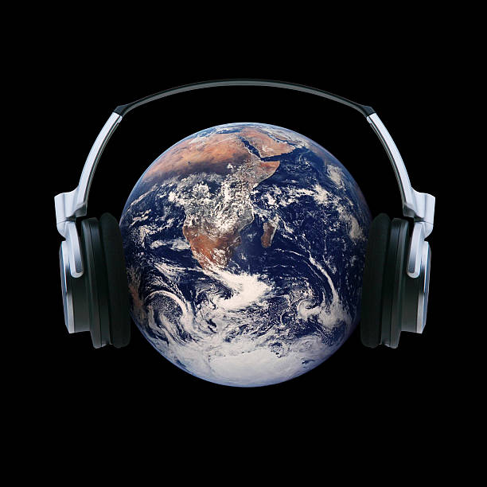

## Packages Required

```r
library(tidyr) # Used to tidy up data
library(tidyverse) #Used to read csv files
library(magrittr) # Used for piping
library(ggplot2) # Used for data visualization
library(dplyr) # Used for data manipulation
library(lubridate) # Used to work with dates
library(DT) # Used to create tables
```

## Data Preparation

- **The original source data can be found [here.](https://canvas.ewu.edu/courses/1540406/files/87301268?module_item_id=14963747)**
- **The code book can be found [here.](https://canvas.ewu.edu/courses/1540406/files/87301268?module_item_id=14963747)**

I used the following codes to analyze the variables in the source data. There are **23 variables**, **32833 observations**, and **15 missing values**. There were 5 missing values each in track name, track artist, and track album name. Although these values are missing, we still have the values for the characteristics and popularity for these observations, thus it will not affect the analysis. My approach to finding duplicates in the data was by looking at the track IDs. If there are duplicates here, then it is highly likely that these observations are indeed duplicated since IDs should be unique to each observation.

```r
#Read and assign data
music_data <- read_csv("Global Music Data.csv", show_col_types = FALSE)

#Identify any outliers or values outside of range
summary(music_data)
```

```
##    track_id          track_name        track_artist       track_popularity
##  Length:32833       Length:32833       Length:32833       Min.   :  0.00
##  Class :character   Class :character   Class :character   1st Qu.: 24.00
##  Mode  :character   Mode  :character   Mode  :character   Median : 45.00
##                                                           Mean   : 42.48
##                                                           3rd Qu.: 62.00
##                                                           Max.   :100.00
##  track_album_id     track_album_name   track_album_release_date
##  Length:32833       Length:32833       Length:32833
##  Class :character   Class :character   Class :character
##  Mode  :character   Mode  :character   Mode  :character
##
##
##
##  playlist_name      playlist_id        playlist_genre     playlist_subgenre
##  Length:32833       Length:32833       Length:32833       Length:32833
##  Class :character   Class :character   Class :character   Class :character
##  Mode  :character   Mode  :character   Mode  :character   Mode  :character
##
##
##
##   danceability        energy              key            loudness
##  Min.   :0.0000   Min.   :0.000175   Min.   : 0.000   Min.   :-46.448
##  1st Qu.:0.5630   1st Qu.:0.581000   1st Qu.: 2.000   1st Qu.: -8.171
##  Median :0.6720   Median :0.721000   Median : 6.000   Median : -6.166
##  Mean   :0.6548   Mean   :0.698619   Mean   : 5.374   Mean   : -6.720
##  3rd Qu.:0.7610   3rd Qu.:0.840000   3rd Qu.: 9.000   3rd Qu.: -4.645
##  Max.   :0.9830   Max.   :1.000000   Max.   :11.000   Max.   :  1.275
##       mode         speechiness      acousticness    instrumentalness
##  Min.   :0.0000   Min.   :0.0000   Min.   :0.0000   Min.   :0.0000000
##  1st Qu.:0.0000   1st Qu.:0.0410   1st Qu.:0.0151   1st Qu.:0.0000000
##  Median :1.0000   Median :0.0625   Median :0.0804   Median :0.0000161
##  Mean   :0.5657   Mean   :0.1071   Mean   :0.1753   Mean   :0.0847472
##  3rd Qu.:1.0000   3rd Qu.:0.1320   3rd Qu.:0.2550   3rd Qu.:0.0048300
##  Max.   :1.0000   Max.   :0.9180   Max.   :0.9940   Max.   :0.9940000
##     liveness         valence           tempo         duration_ms
##  Min.   :0.0000   Min.   :0.0000   Min.   :  0.00   Min.   :  4000
##  1st Qu.:0.0927   1st Qu.:0.3310   1st Qu.: 99.96   1st Qu.:187819
##  Median :0.1270   Median :0.5120   Median :121.98   Median :216000
##  Mean   :0.1902   Mean   :0.5106   Mean   :120.88   Mean   :225800
##  3rd Qu.:0.2480   3rd Qu.:0.6930   3rd Qu.:133.92   3rd Qu.:253585
##  Max.   :0.9960   Max.   :0.9910   Max.   :239.44   Max.   :517810
```

```r
#Get dimension of data
dim(music_data)
```

```
## [1] 32833    23
```

```r
#Find how many missing values
colSums(is.na(music_data))
```

```
##                 track_id               track_name             track_artist
##                        0                        5                        5
##         track_popularity           track_album_id         track_album_name
##                        0                        0                        5
## track_album_release_date            playlist_name              playlist_id
##                        0                        0                        0
##           playlist_genre        playlist_subgenre             danceability
##                        0                        0                        0
##                   energy                      key                 loudness
##                        0                        0                        0
##                     mode              speechiness             acousticness
##                        0                        0                        0
##         instrumentalness                 liveness                  valence
##                        0                        0                        0
##                    tempo              duration_ms
##                        0                        0
```

```r
#Find duplicates
duplicated(music_data$track_id)
```

For cleaning the data, I decided to remove variables that are not related to my focus. I did remove some characteristics such as mode, key, speechiness, and liveness as we determined that these would not provide significant information in determining popularity. Then I removed duplicates by the track_id since ID’s should be unique to each observation. Additionally, having the duration of songs be in milliseconds is not very intuitive, so I changed this variable to be in minutes and then changed the variable name to be duration. There were 6 values in the variable “loudness” that were outside the range (0 to -60) that loudness is measured in. To keep these variables within the range without entirely removing the observation, I changed all values that were greater than 0 to the median of the loudness variable. Lastly, I converted the track album release date variable to a date format and created a new variable called release year and extracted just the year. I then removed the track album release date since we now have the year and the months/days isn’t as important.

```r
# Cleaning the data

#Remove duplicates
clean_music <- music_data[!duplicated(music_data$track_id), ]
duplicated(clean_music$track_id)
str(clean_music)

# Remove unnecessary/unused variables
clean_music <- select(clean_music, -c(track_id, track_album_id, playlist_id, track_name, track_artist, track_album_name, playlist_name, playlist_subgenre, playlist_genre, key, mode, speechiness, liveness ))



# Change variable "duration_ms" from milliseconds to minutes, rename, & round
clean_music$duration_ms <- ((clean_music$duration_ms/1000)/60)
clean_music <- rename(clean_music, duration = duration_ms)
round(clean_music$duration, digits = 2)


# Data Imputation - Look at values outside of variable range and change to median
filter(clean_music, loudness > 0)
clean_music$loudness[clean_music$loudness == 1.275] <- median(clean_music$loudness, na.rm = TRUE)
clean_music$loudness[clean_music$loudness == 0.551] <- median(clean_music$loudness, na.rm = TRUE)
clean_music$loudness[clean_music$loudness == 0.326] <- median(clean_music$loudness, na.rm = TRUE)
clean_music$loudness[clean_music$loudness == 0.642] <- median(clean_music$loudness, na.rm = TRUE)
clean_music$loudness[clean_music$loudness == 1.135] <- median(clean_music$loudness, na.rm = TRUE)
clean_music$loudness[clean_music$loudness == 0.302] <- median(clean_music$loudness, na.rm = TRUE)

# Convert to Date & extract year

clean_music$track_album_release_date <- sub(".*(\\d+{4}).*$", "\\1", clean_music$track_album_release_date)
clean_music <- rename(clean_music, release_year = track_album_release_date)
summary(clean_music)
sum(is.na(clean_music$release_year))
unique(clean_music$release_year)
clean_music$release_year <- as.Date(clean_music$release_year, "%Y")
clean_music$release_year <- year(clean_music$release_year)
summary(clean_music$release_year)
```

```r
# Verify all changes have been made
summary(clean_music) # Show all Variables are within range
str(clean_music) # Show all duplicated values (less observations)
```

### Cleaned data table

```r
# Show cleaned data in condensed form
datatable(head(clean_music, 8), options = list(scrollX = TRUE))
```

|  | track_popularity | release_year | danceability | energy | loudness | acousticness | instrumentalness | valence | tempo | duration |
| --- | --- | --- | --- | --- | --- | --- | --- | --- | --- | --- |
| 1 | 66 | 2019 | 0.748 | 0.916 | -2.634 | 0.102 | 0 | 0.518 | 122.036 | 3.2459 |
| 2 | 67 | 2019 | 0.726 | 0.815 | -4.969 | 0.0724 | 0.00421 | 0.693 | 99.972 | 2.71 |
| 3 | 70 | 2019 | 0.675 | 0.931 | -3.432 | 0.0794 | 2.33e-05 | 0.613 | 124.008 | 2.9436 |
| 4 | 60 | 2019 | 0.718 | 0.93 | -3.778 | 0.0287 | 9.43e-06 | 0.277 | 121.956 | 2.81821666666667 |
| 5 | 69 | 2019 | 0.65 | 0.833 | -4.672 | 0.0803 | 0 | 0.725 | 123.976 | 3.15086666666667 |
| 6 | 67 | 2019 | 0.675 | 0.919 | -5.385 | 0.0799 | 0 | 0.585 | 124.982 | 2.71748333333333 |
| 7 | 62 | 2019 | 0.449 | 0.856 | -4.788 | 0.187 | 0 | 0.152 | 112.648 | 3.12791666666667 |
| 8 | 69 | 2019 | 0.542 | 0.903 | -2.419 | 0.0335 | 4.83e-06 | 0.367 | 127.936 | 3.46031666666667 |

### Summary of cleaned data with variables names, type, and description

The data is looking ready for some exploratory analysis. I have provided the ranges to expect as well as what they mean in the description for each variable.

```r
#Summary of data (Variable, Type, & Description)
data_summary <- as_tibble(cbind(Variable, Type, Description))
DT::datatable(head(data_summary, 14))
```

|  | Variable | Type | Description |
| --- | --- | --- | --- |
| 1 | track_popularity | int | Song popularity (0-100) where higher is better |
| 2 | danceability | num | How suitable a track is for dancing. Value of 0.0 is least danceable and 1.0 is most danceable |
| 3 | energy | num | Energy is a measure from 0.0 to 1.0 and represents a perceptual measure of intensity and activity. |
| 4 | loudness | num | The overall loudness of a track in decibels (dB). Values typical range between -60 and 0 db. |
| 5 | acousticness | num | A confidence measure from 0.0 to 1.0 of whether the track is acoustic. 1.0 represents high confidence the track is acoustic. |
| 6 | instrumentalness | num | The closer the instrumentalness value is to 1.0, the greater likelihood the track contains no vocal content. Values above 0.5 are intended to represent instrumental tracks, but confidence is higher as… |
| 7 | valence | num | A measure from 0.0 to 1.0 describing the musical positiveness conveyed by a track. Tracks with high valence sound more positive (e.g. happy, cheerful, euphoric), while tracks with low valence sound mo… |
| 8 | tempo | num | The overall estimated tempo of a track in beats per minute (BPM). In musical terminology, tempo is the speed or pace of a given piece and derives directly from the average beat duration. |
| 9 | duration | num | Duration of song in minutes |
| 10 | release_year | num | The year the track was released. |

## Exploratory Analysis

The first step to uncover information in the data was to create new variables. The first variable I created was track ratings which separated different ratings into either bottom, fair, moderate, satisfactory, or top tracks. The second variable I created was era which categorized release years into either pre-2000s, early 2000s, or current (ranging from 2015-2020). Having these new variables makes visualizing the data more efficient and easier to identify trends.

To visualize the impact of characteristics on popularity of tracks, I created boxplots that used the specific characteristics compared to the track ratings and the era in which it was released. Two characteristics,instrumentalness and valence, did not give enough information with boxplots, thus I created additional graphs to gain further insights.

To visualize the impact duration has on popularity, I decided to only compare the bottom tracks and top tracks in track ratings with duration using histograms. This process allowed me to simplify the data while maintaining the focus on my primary goal of answering what makes a track popular.

### Creating New Variables

```r
#Adding new variable that categorizes track popularity ratings
clean_music <- clean_music %>%
  mutate(track_ratings = case_when((track_popularity < 10) ~ "bottom tracks",
         (track_popularity >= 10) & (track_popularity < 50) ~ "fair tracks",
         (track_popularity >= 50) & (track_popularity < 75) ~ "moderate tracks",
         (track_popularity >= 75) & (track_popularity < 90) ~ "satisfactory tracks",
         (track_popularity >= 90) ~ "top tracks"))
#Check how many counts for each category
table(clean_music$track_ratings)
```

```
##
##       bottom tracks         fair tracks     moderate tracks satisfactory tracks
##                5000               12376                9635                1289
##          top tracks
##                  56
```

```r
#Adding new variable that categorizes release year by era

clean_music <- clean_music %>%
  mutate(era = case_when((release_year < 2000) ~ "Pre-2000s",
         (release_year >= 2000) & (release_year < 2015) ~ "early 2000s",
         (release_year >= 2015) ~ "Current (2015-Now)"))

#Check how many counts for each category
table(clean_music$era)
```

```
##
## Current (2015-Now)        early 2000s          Pre-2000s
##              16501               7766               4089
```

### Characteristics by Era & Popularity Plots

#### Energy

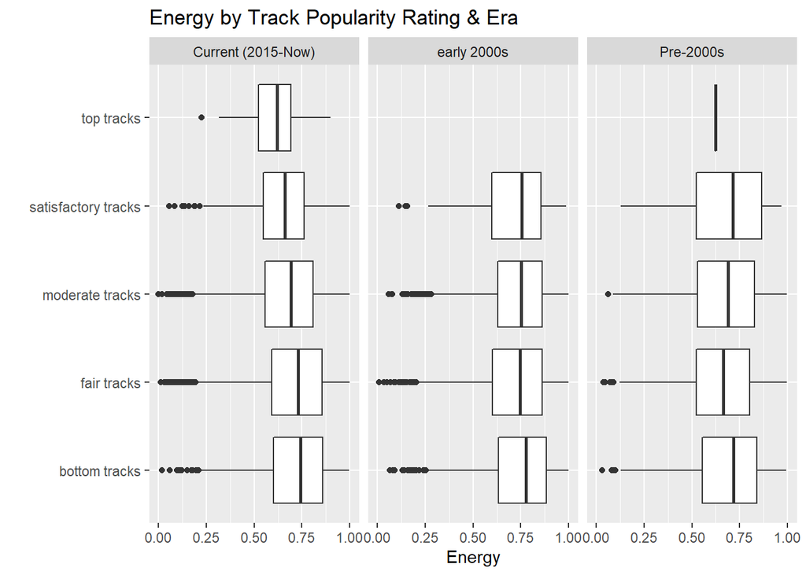

```r
clean_music %>%
  ggplot(aes(x = track_ratings, y = energy))+
  geom_boxplot() +
  facet_wrap(~era) +
  coord_flip()+
  ggtitle("Energy by Track Popularity Rating & Era")+
  labs(x = " ", y = "Energy")
```

#### Danceability

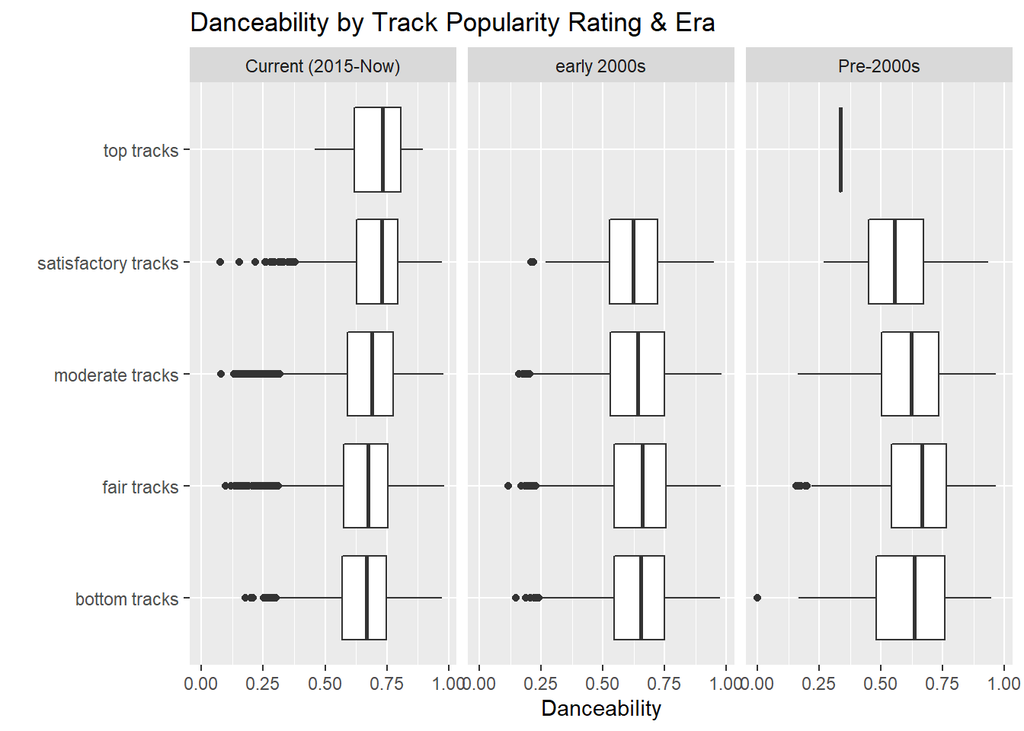

```r
clean_music %>%
  ggplot(aes(x = track_ratings, y = danceability)) +
  geom_boxplot() +
  facet_wrap(~era) +
  coord_flip()+
  ggtitle("Danceability by Track Popularity Rating & Era")+
  labs(x = " ", y = "Danceability")
```

#### Loudness

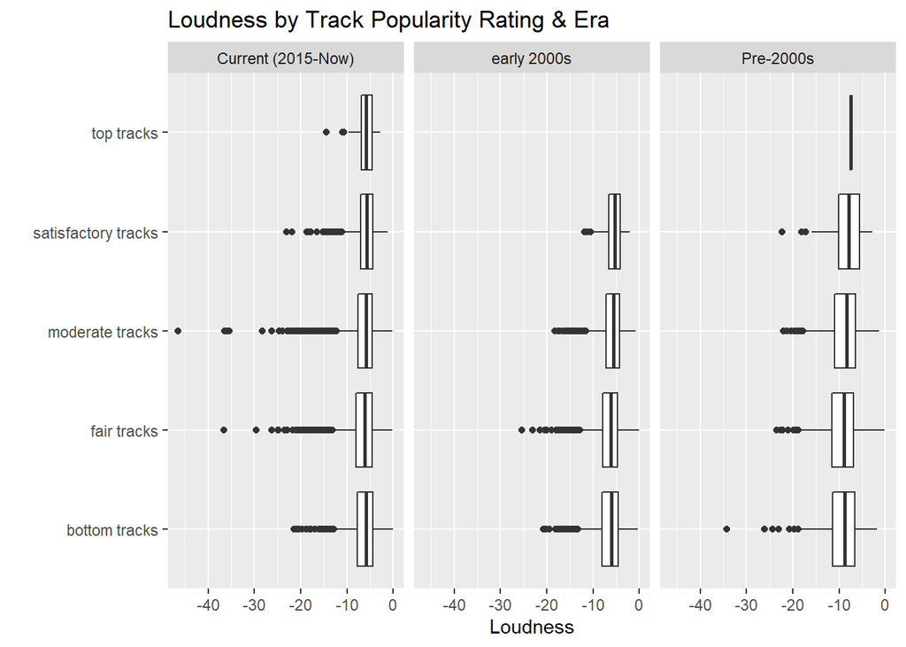

```r
clean_music %>%
  ggplot(aes(x = track_ratings, y = loudness)) +
  geom_boxplot() +
  facet_wrap(~era) +
  coord_flip()+
  ggtitle("Loudness by Track Popularity Rating & Era")+
  labs(x = " ", y = "Loudness")
```

#### Acousticness

In both the current and pre-2000s eras, as acousticness goes up, so does the popularity. In the early 2000s tracks, only the bottom tracks had slightly less acousticness. Thus we concluded that more acousticness does indicate that a track will be more popular.

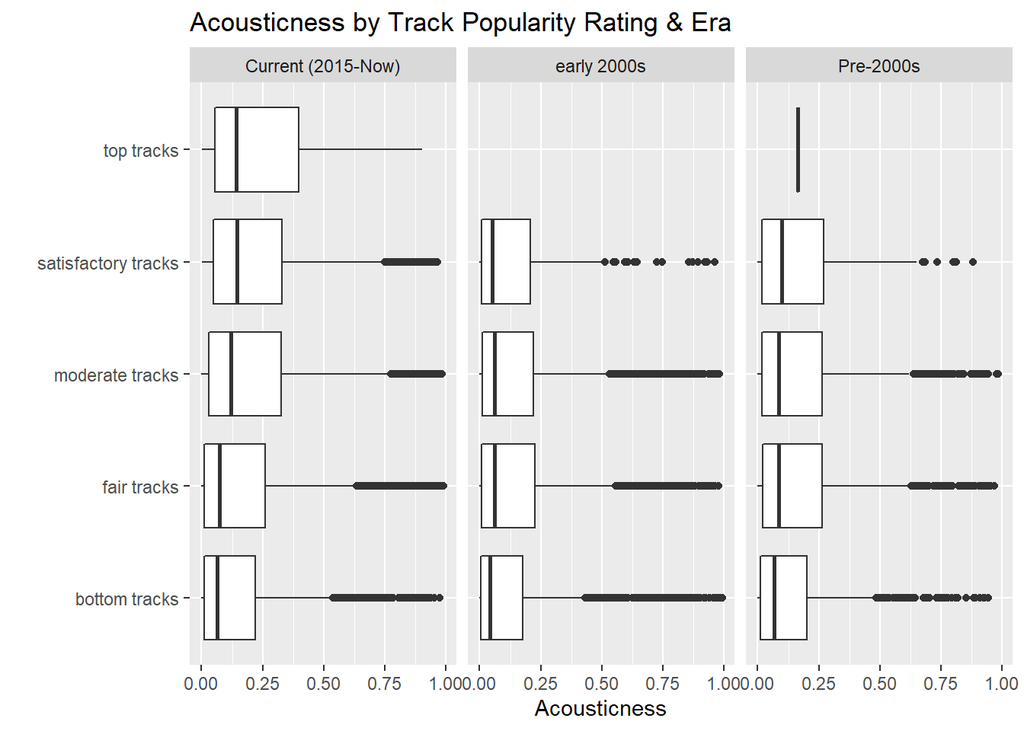

```r
clean_music %>%
  ggplot(aes(x = track_ratings, y = acousticness)) +
  geom_boxplot() +
  facet_wrap(~era) +
  coord_flip()+
  ggtitle("Acousticness by Track Popularity Rating & Era")+
  labs(x = " ", y = "Acousticness")
```

#### Instrumentalness

The boxplots are not giving us much information with how popularity, instrumentalness, and eras correlate. We can see that all tracks have around the same range of instrumentalness, which is close to zero. To look further into this I created a scatterplot comparing just the instrumentalness and track popularity. I decided to take the top 15,000 tracks to have enough data to come to a conclusion. Adding a trend line helps us see where most of the distribution lies and how instrumentalness plays a role in popularity.

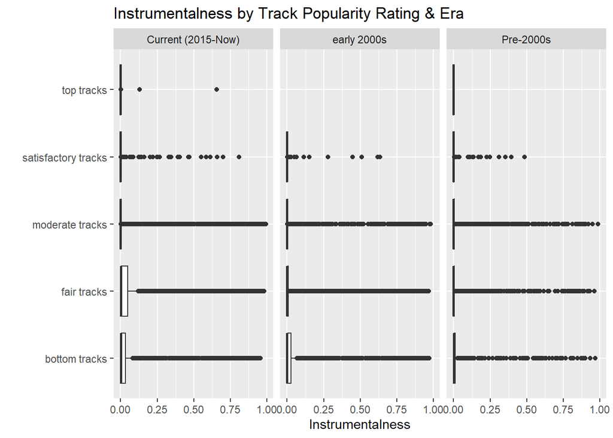

```r
clean_music %>%
  ggplot(aes(x = track_ratings, y = instrumentalness)) +
  geom_boxplot() +
  facet_wrap(~era) +
  coord_flip()+
  ggtitle("Instrumentalness by Track Popularity Rating & Era")+
  labs(x = " ",  y = "Instrumentalness")
```

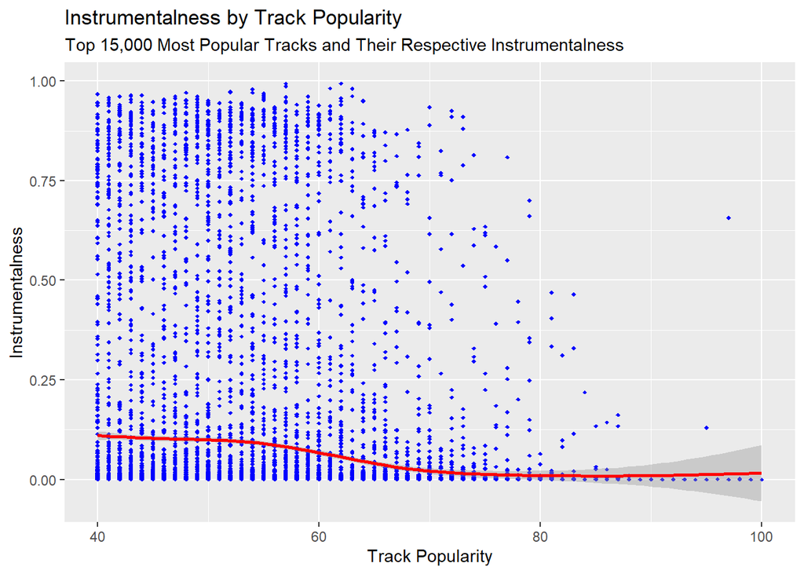

```r
#Instrument Graph without era

#Looking at how Track Popularity and Instrumentalness Correlate;
#Arranged from Most Popular to Least Popular

top_15000_most_popular_with_instrumentalness <- clean_music %>%
  arrange(desc(track_popularity)) %>%
  select(track_popularity, instrumentalness) %>%
  slice_max(track_popularity, n = 15000)

ggplot(data = top_15000_most_popular_with_instrumentalness, aes(x= track_popularity, y = instrumentalness)) +
  geom_point(color = "blue", size = 1, shape = 18) +
  geom_smooth(stat = 'smooth', color = 'red', method = 'gam', formula = y ~ s(x, bs = "cs")) +
  ggtitle("Instrumentalness by Track Popularity",
          subtitle = "Top 15,000 Most Popular Tracks and Their Respective Instrumentalness")+
  scale_x_continuous(name = "Track Popularity")+
  scale_y_continuous(name = "Instrumentalness")
```

#### Valence

Current tracks are more popular the higher the valence is, but with early and pre-2000s tracks, the most popular tracks had lower valence than the bottom tracks. One thing we found interesting was how the overall valence has gone down in current tracks compared to the other eras so we wanted to dig a little deeper into this by creating histograms of just valence and eras without the popularity ratings.

The histograms show that the majority of tracks in the current era have a valence of around .30 whereas early 2000s tracks were mostly around .55 and the pre-2000s tracks had an even higher majority valence of around .70. This shows that tracks, regardless of popularity, are trending with lower valence, meaning less happy/cheerful and more sad/depressing.

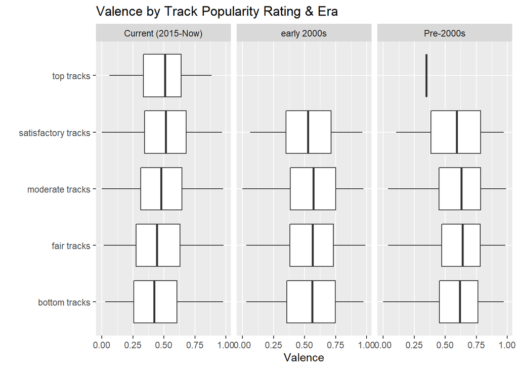

```r
clean_music %>%
  ggplot(aes(x = track_ratings, y = valence)) +
  geom_boxplot() +
  facet_wrap(~era) +
  coord_flip()+
  ggtitle("Valence by Track Popularity Rating & Era")+
  labs(x = " ", y = "Valence")
```

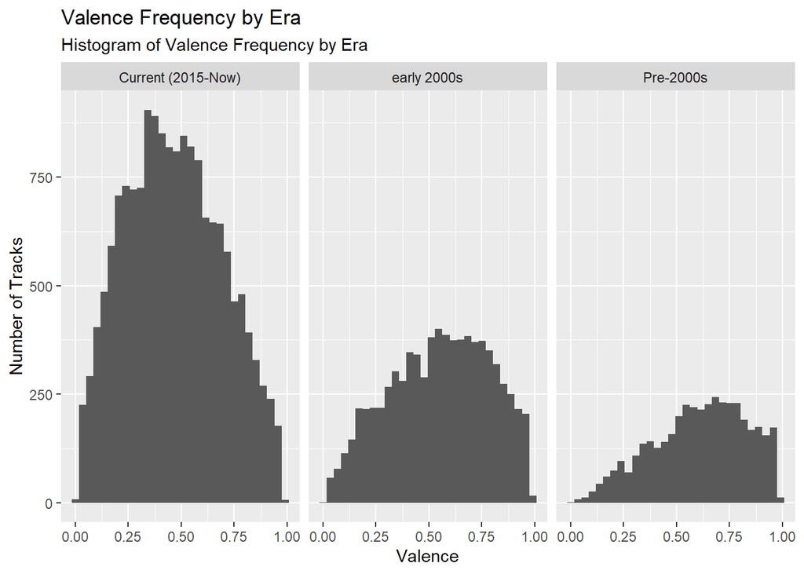

```r
#Graph of just valence and era

clean_music %>%
  ggplot(aes(x = valence)) +
  geom_histogram() +
  facet_wrap(~era)+
  ggtitle("Valence Frequency by Era", subtitle = "Histogram of Valence Frequency by Era")+
  labs(x = "Valence", y = "Number of Tracks")
```

#### Tempo

Tempo, outside of the top tracks in the pre-2000s era, stays relatively the same in all eras and popularity. We determined that tempo is not a good indicator of whether a track will be popular.

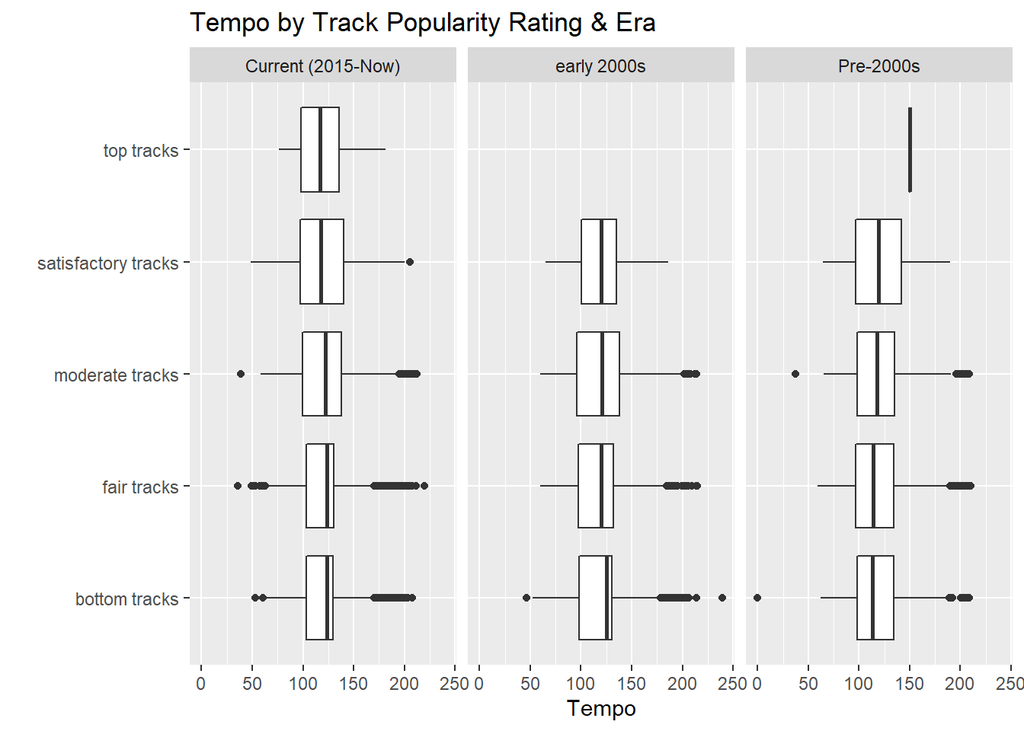

```r
clean_music %>%
  ggplot(aes(x = track_ratings, y = tempo)) +
  geom_boxplot() +
  facet_wrap(~era) +
  coord_flip()+
  ggtitle("Tempo by Track Popularity Rating & Era")+
  labs(x = " ", y = "Tempo")
```

### Duration Plots

#### Bottom Tracks

The majority of the tracks with the lowest popularity ratings have a duration of around 3.5 - 4 minutes. There were many tracks that were 5 minutes or longer and even some tracks were less than 2 minutes long.

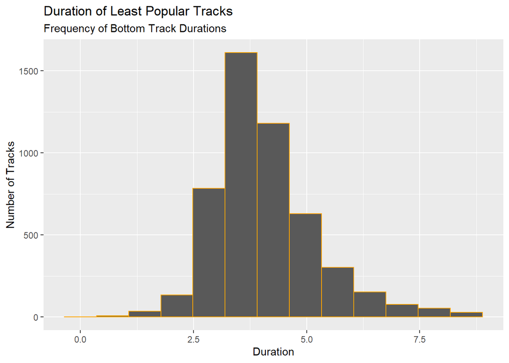

```r
#Creating data frame with just top tracks and duration
bottom_duration <- clean_music %>%
  filter(track_ratings == "bottom tracks") %>%
  select(track_ratings, duration)


ggplot(data = bottom_duration, aes(x = duration)) +
  geom_histogram(bins = 13, color = "orange")+
  ggtitle("Duration of Least Popular Tracks", subtitle = "Frequency of Bottom Track Durations")+
  labs(x = "Duration", y = "Number of Tracks")
```

#### Top Tracks

The majority of the tracks with the highest popularity ratings were around 2.75 to 4.25 minutes long with no songs going over the 5.5 minute mark.

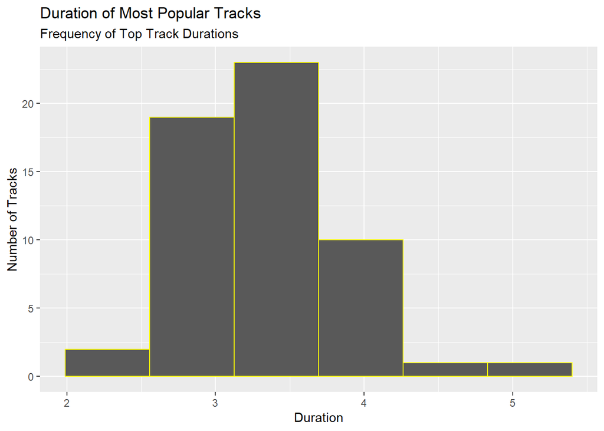

```r
#Creating data frame with just top tracks and duration
top_duration<- clean_music %>%
  filter(track_ratings == "top tracks") %>%
  select(track_ratings, duration)

ggplot(data = top_duration, aes(x = duration)) +
  geom_histogram(bins = 6, color = "yellow") +
  ggtitle("Duration of Most Popular Tracks", subtitle = "Frequency of Top Track Durations")+
  labs(x = "Duration", y = "Number of Tracks")
```

## Summary of Findings

I wanted to find the characteristics that determined a track’s popularity rating and whether the duration of the track played a role in its’ popularity. I also sought out to find any obvious trends of how music has changed over time. I discovered that danceability, loudness, and tempo were not great indicators on determining whether a track will be popular, with the exception of current tracks having a preference of a higher danceability measure. Energy is also not a great indicator, however, I found that it does show a trend that more recent tracks are higher rated when energy is lower and around .60-.65 on the scale.

Acousticness showed a definite trend that the higher the confidence measure of acoustics in a track, the higher it was rated. And with instrumentalness, tracks were rated significantly higher the closer the instrumentalness got to zero.

As for duration, most tracks, regardless of popularity, ran around 3-4 minutes long. However, only the most popular tracks did not ever exceed 5.5 minutes or fell below 2 minutes long.

My suggestion for those in the music industry is to create tracks that have a good amount of acoustics and vocals. The track should be around 3.5 minutes long and have a mellow vibe that is neither too happy or too sad.

**Final notes:**

If I were to build onto this data to improve it, it would be insightful to see the popularity of the tracks at the time it was released, rather than just how popular the tracks are today. This would give a clearer picture of how the music industry has evolved over time and what music consumers were looking for then and what they are looking for now.